# Modelling Peak Electricity Demand in Great Britain

Group 50, Ella Park (s2311400), Saioa Galvin (s2516907), Kieran Marguerie de Rotrou (s2536961), (3,226 words)

# Introduction

Accurately forecasting future daily peak electricity demand is crucial for NESO especially during winter when cold weather drives up demand and the risk of shortfalls is highest. To help anticipate extreme scenarios, we focus on modelling the upper tail of the demand distribution to help NESO allocate reserves efficiently.

We use historical daily peak demand data from the `SCS_demand_modelling.csv`, covering winter months from November 1991 to March 2014 across Great Britain. Each row represents a single day, describing electricity demand and capturing key factors that influence this including weather conditions and renewable energy generation.

This report develops and refines a linear regression model to forecast peak demand starting with a baseline model $M_0$ using weather and temporal predictors. Refinements include additional covariates, long-term trends, and improved temperature metrics. To compare and select our best model, we evaluate how our model fits historic data, predictive accuracy and how peak demand varies under different weather conditions. To compare prediction accuracy, we construct a rolling-window cross-validation scheme that computes prediction scores across months and then weekdays versus weekends.

The final model is selected for its predictive performance and interpretability, providing NESO with a reliable forecasting tool. We also highlight limitations and suggest future improvements, such as incorporating recent data and more complex dependencies.

# Data description and exploratory analysis

A thorough understanding of the dataset is essential for effective forecasting. This section highlights important patterns through visualizations to inform model development and summarizes the pre-analysis steps undertaken.

During preprocessing, we confirmed that there were no missing values in the dataset. Outliers were reviewed for potential input errors, but no evidence warranted their removal, ensuring data quality for model fitting. This was also confirmed when checking the Cook’s distance on leverage plots of our final model. The nature of each variable was checked to ensure correct data types (e.g. continuous, categorical) and categorical variables were renamed for easier analysis.

Our analysis begins by analysing how continuous predictors, $wind$, $solar\_S$, $TE$ (temperature) and $year$ relate to the response variable, peak electricity demand ($demand\_gross$).

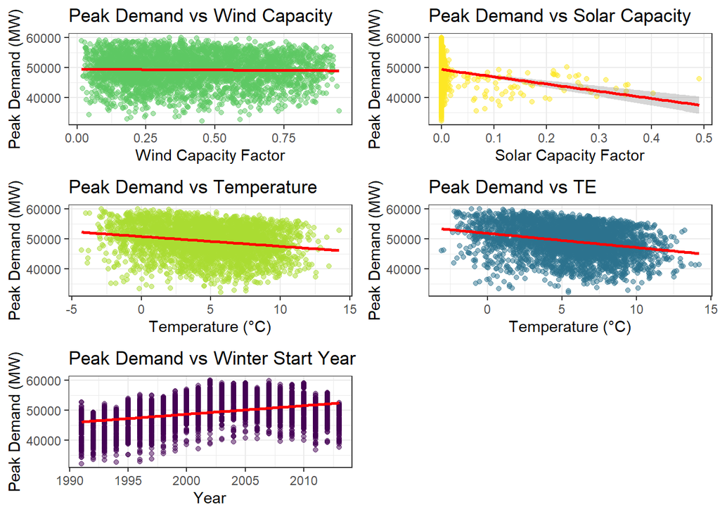

The scatter plot between wind capacity factor and daily peak electricity demand shows a weak relationship, suggesting wind generation has minimal impact on peak demand. This is expected as demand peaks are probably more likely to be influenced by factors like temperature.

The wind variable, though not a strong predictor, was statistically significant in our final model with a regression coefficient of 898.17, even at the 1% significance level. Additionally, we used the $\texttt{step}$ function to perform backward stepwise regression on another of our models. This method iteratively removes variables that do not contribute significantly to the model, based on the Akaike Information Criterion (AIC). Despite its weak relationship, wind remained in the model we conducted this on as its removal did not improve the AIC, indicating it still plays a role in predicting demand.

Most points fall below 0.05, showing little correlation between solar and demand. However, a slight negative correlation appears beyond this threshold, suggesting that higher solar generation reduces peak demand. This is intuitive, as increased solar output reduces electricity needs for lighting supporting the inclusion of solar as an explanatory variable in our model.

Both the scatter plots of temperature and TE against demand show a negative correlation where higher temperatures generally correspond to a lower electricity demand. This relationship is expected, as higher temperatures tend to reduce the need for heating, a significant factor in electricity demand during colder months. Given the clear consistent negative correlation, it was important to include one temperature variable in the model.

Since both temperature and TE are based on similar data, including both could introduce multicollinearity, so we select only one. TE shows slightly less variation in demand compared to temperature as it incorporated data from the previous day, smoothing out the fluctuations. This makes TE a more stable representation of the temperature’s influence on demand helping the model to capture long term temperature trends better than temperature alone. This helps to provide the hypothesis that TE is a more valuable measure of temperature than the temp variable. Subsequent analysis will provide further evidence for this.

The plot reveals a correlation, suggesting that demand increases over time. However from this it is evident the relationship is more complex than a simple linear trend, following a cubic pattern. There are a variety of reasons which this occurs such as reflecting long-term trends in energy usage, economic growth, policy changes or technological advancements. The following graphs visualize this hypothesis to assess whether a quadratic or cubic term improves the model’s fit compared to the linear one.

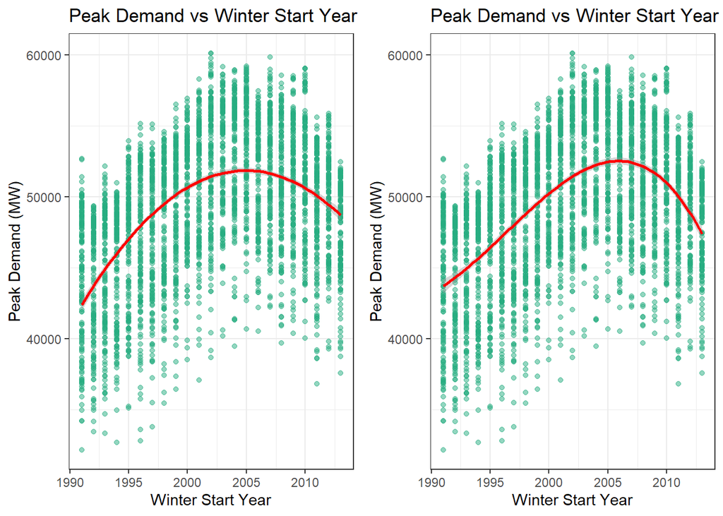

Next we investigate the effect of categorical on peak demand by analysing its variation across different days of the week and months using violin plots.

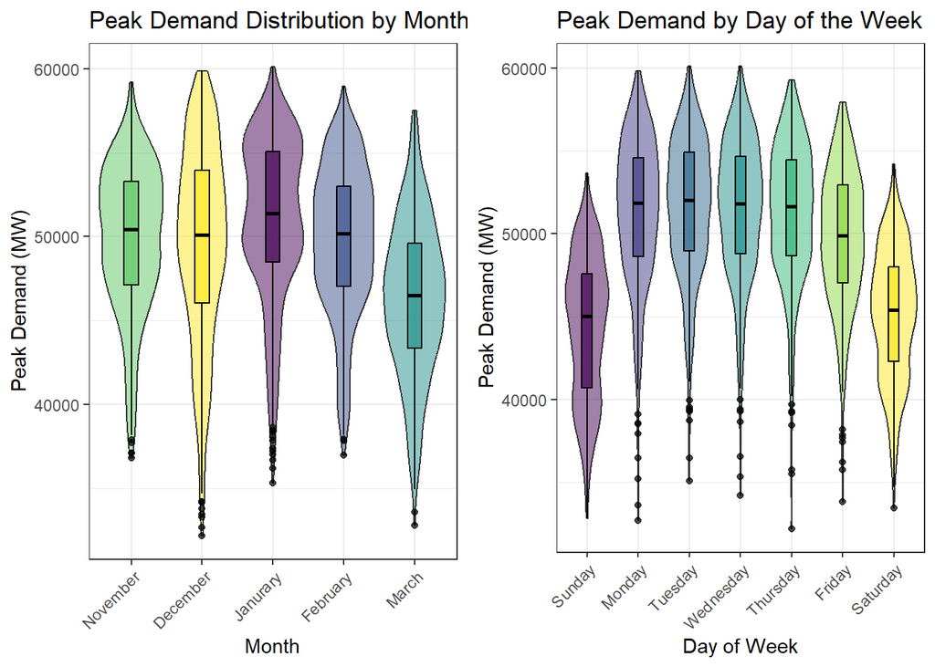

The first plot illustrates the distribution of peak demand across different months. While the peak demand across most months appears relatively consistent, March has a noticeably lower demand. This drop in demand is possibly due to improving weather and decreased heating demand. Given this distinct difference This suggests that the month variable will be an important factor in the model.

The violin plot for day of the week shows that peak electricity demand is generally higher on weekdays than weekends, reflecting increased consumption from offices and factories.

|  | Day | Median | Q1 | Q3 |
| --- | --- | --- | --- | --- |
| 0 | Sunday | 45018.50 | 40715.50 | 47587.00 |
| 1 | Monday | 51883.50 | 48624.88 | 54581.00 |
| 2 | Tuesday | 52041.00 | 48950.50 | 54914.00 |
| 3 | Wednesday | 51837.50 | 48802.00 | 54681.00 |
| 4 | Thursday | 51671.75 | 48671.38 | 54480.88 |
| 5 | Friday | 49887.50 | 47047.00 | 52960.00 |
| 6 | Saturday | 45401.00 | 42298.00 | 48025.00 |

While it may seem reasonable to simplify the model by grouping weekends, this overlooks important differences, particularly Friday, which has a median peak nearly 2,000 MW lower than other weekdays. Weekdays overall are fairly consistent, with median peaks around 52,000 MW, compared to about 45,000 MW on weekends. Including day of the week as a factor variable captures these variations without oversimplifying, and later analysis confirms its statistical significance.

The next step is to explore interactions that can help improve the model accuracy. Interactions allow us to capture relationships where the effect of one variable on peak demand depends on the value of another.

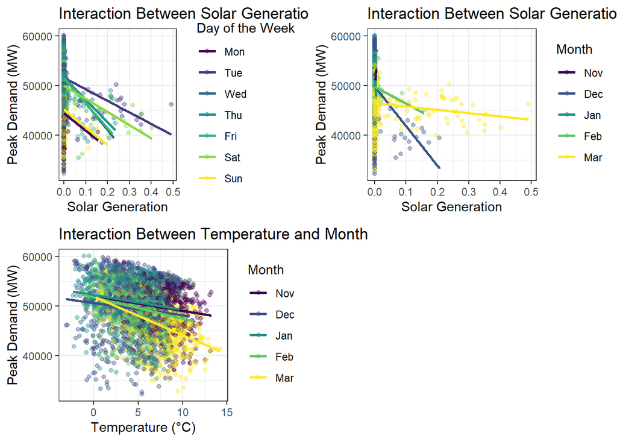

# Model fitting and cross-validation results

## Other Models Considered

To develop a robust forecasting model for daily peak electricity demand, we explored several model formulations and refined them using stepwise selection.

The provided base model, $m0$, accounted for key weather and temporal factors but overlooked categorical nature of both `wdayindex` (day of the week) and `monthindex` (month) which was an inappropriate simplification. We corrected this by modelling them as factors.

Additionally, long-term trends were not captured, despite exploratory analysis suggesting a cubic relationship between demand and year. This insight led to the inclusion of `poly(year, 3)`. This was selected instead over the non-orthogonal polynomial, `year + I(year^2) + I(year^3)` since poly generates orthogonal polynomials ensuring the terms are uncorrelated to reduce multicollinearity.

Based on earlier findings, we also replaced temp with TE as it smoothed out short-term fluctuations and incorporated the lagged effects from previous days’ temperatures, providing a more accurate predictor of peak demand.

Our earlier plots also revealed the potential importance of interactions between variables on peak demand. Therefore, it was important our model contained at least two way interactions to accurately capture the relationships and improve predictive power. However, to mitigate the risk of overfitting and reduce the number of unnecessary explanatory variables, we refined the model further by applying backward stepwise regression. This method begins with the full model and iteratively removed the least significant variables. At each step, the model’s performance is assessed using the Akaike Information Criterion (AIC), which balances model fit and complexity. The predictor that results in the smallest increase in AIC is removed, and the process continues until no further improvements can be made.

However, our analysis concluded that a simpler model without interactions had better predictive ability than a one without interactions. This led us to the final model This leaves us with the final model:
$$\begin{aligned}
M_1: \text{Peak Demand} &= \beta_0 + \beta_1 \cdot \text{wind} +
\beta_2 \cdot \text{solar}_S + \beta_3 \cdot \text{TE} \\
&+ \sum_{i=1}^{6} \beta_{i+3} \cdot \text{day}_i + \sum_{j=1}^{3}
\beta_{j+9} \cdot \text{month}_j \\
&+ \beta_{12} \cdot \text{poly(year, 3)}_1 + \beta_{13} \cdot
\text{poly(year, 3)}_2 + \beta_{14} \cdot \text{poly(year, 3)}_3 +
\varepsilon_i
\end{aligned}$$
where $\text{demand_gross}_i$ is the peak demand at the time $i$, $\beta_j$ for $j=0,1,\dots,7$ are the regression coefficients and the $\varepsilon\sim\mathcal{N}(0,\sigma^2)$ is the error term at time $i$.

To evaluate the models to consider, the most important metrics to consider are the $R^2$ and Adjusted $R^2$ scores, and Root Mean Squared Error ($RMSE$). These metrics for each model are shown in the following table.

| Model | $R^2$ | Adjusted $R^2$ | RMSE |
| --- | --- | --- | --- |
| m0 | 0.0645912 | 0.0632446 | 4947.830 |
| Poly start_year, TE, interactions | 0.7634710 | 0.7623779 | 2488.034 |
| Poly start_year, TE, interactions, poly daytype | 0.4967597 | 0.4951631 | 3629.124 |
| Interactions | 0.8162251 | 0.8101102 | 2193.093 |
| Backward Step on Interactions | 0.8153243 | 0.8101944 | 2198.462 |
| No interactions | 0.7734350 | 0.7723879 | 2435.064 |

The final three rows of this table are the most significant, as we are comparing the following models to see the importance of interactions between explanatory variables for our model.

No interactions model:

$$demand\_gross \sim wind + solar\_S + TE
+ day + month + poly(year, 3) + \varepsilon.$$

All interactions model:

$$demand\_gross \sim (wind + solar\_S + TE
+ day + month + poly(year, 3))^2 + \varepsilon.$$
Backward step on all interactions model:

$$demand\_gross \sim wind + solar\_S + TE
+ day + month + poly(year, 3) + \\
wind:month + wind:poly(year, 3) + \\
solar\_S:day + solar\_S:month + \\
TE:month + TE:poly(year, 3) + \\
day:month + day:poly(year, 3) + \\
month:poly(year, 3) + \varepsilon.$$

In this table we are evaluating the results of the model fitting by checking metrics.

The $R^2$ metrics evaluate how well the model fits the response data, written as $R^2 = 1 − \frac{\frac{1}{n} \sum_{i = 1}^n \hat{\varepsilon_i}^2}{\frac{1}{n} \sum_{i = 1}^n (y_i - \bar{y})^2}$. Additionally, we can analyse Adjusted $R^2$, which uses unbiased estimators, because $R^2$ can overestimate how well a model is doing. We have $R_{adj}^2 = 1 − \frac{\frac{1}{n-p} \sum_{i = 1}^n \hat{\varepsilon_i}^2}{\frac{1}{n-1} \sum_{i = 1}^n (y_i - \bar{y})^2}$, where $p$ is the number of model parameters. We want our $R^2$ values to be as close as possible to 1 to indicate a close fit.

## Testing on Historical Data

As well as metrics, the validity of our model can be shown by testing on historical data.

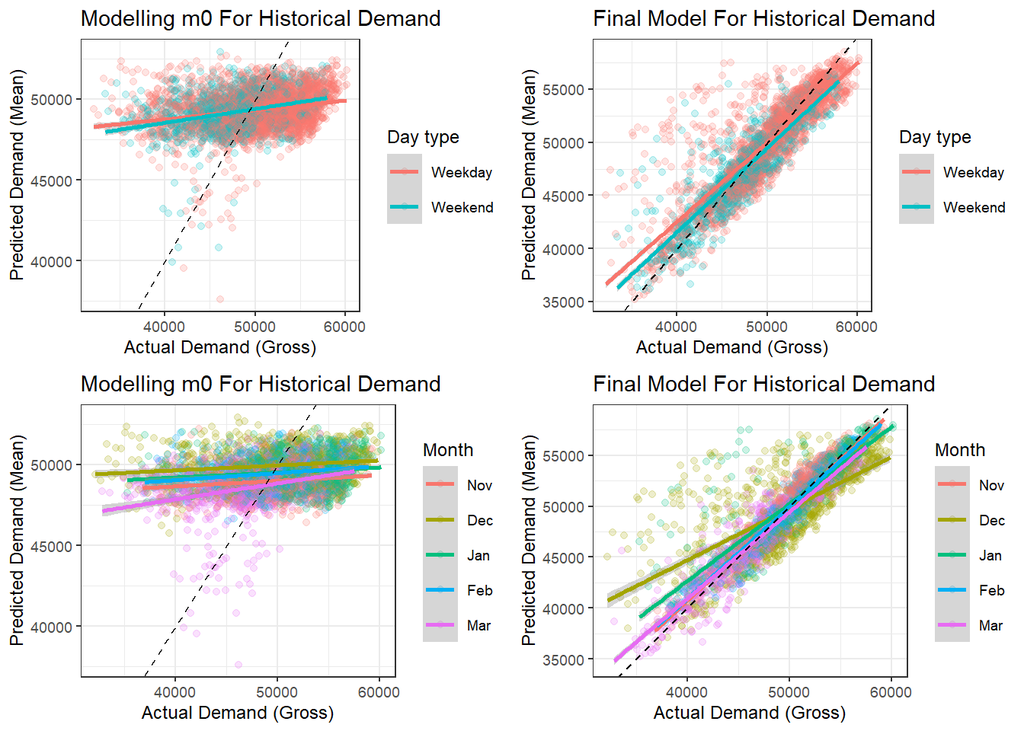

These plots show that our final model is a much better fit on historical data than $m0$, as the best-fit lines are all closer to the $y=x$ line.

### Residuals

To check the modelling assumptions of the residuals for our model, we consider the following graphs.

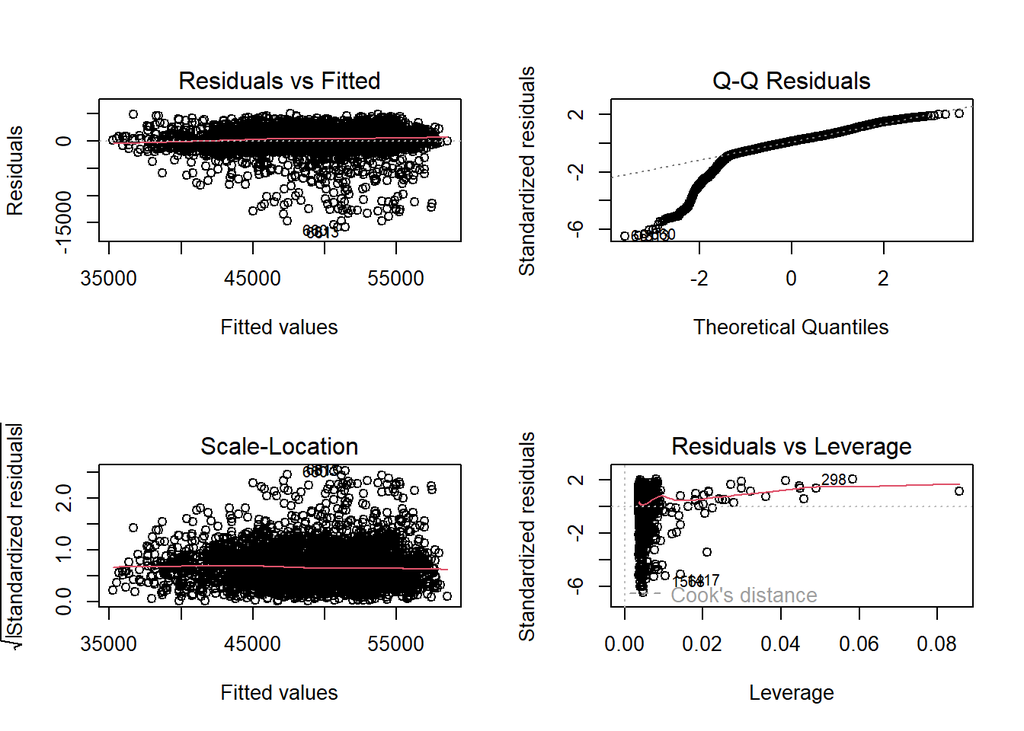

The Residuals vs Fitted plot shows little change of variance with mean, so the constant variance assumption is upheld. The Q-Q Residuals plot the ordered standardised residuals against quantiles of a standard normal. For smaller sample size, the normality assumption is violated, but we can apply the central limit theorem in this case. Therefore this deviation from the normal line is not very significant. The values on the Scale-Location plot shows random variation around the mean, confirming no violation of the constant variance assumption. Finally, the residuals vs leverage plot gives us Cook’s distance, which measures the change in all model fitted values on omission of the data point in question. Here, it is not problematic, so we can conclude that there are no outliers that need investigating for our model.

## Cross-Validation

In addition to testing on historical data, we test the final model on future data using rolling-window cross-validation.

First, it is important to note that our data now has `daytype` and `month` as factor variables. As we are using time-series data, we perform rolling-window cross-validation training the model on 3 years and testing on the subsequent year, shifting the window forward annually. This compares the basic model, $m_0$ with the final model across winter months.

| Model | Mean SE | Mean DS | Mean Interval Score |
| --- | --- | --- | --- |
| Backward | 48949836 | 18.35818 | 33621.38 |
| Interactions | 2506009127 | 18.52262 | 87506.23 |
| No Interactions (final) | 8785933 | 17.03901 | 16779.34 |
| m0 | 17927943 | 17.68907 | 18609.75 |

This table shows the average Squared Error ($SE$), average Dawid-Sebastiani score ($DS$) and the average Interval score for the basic model and our final model. As these are negatively-oriented scores, smaller values indicate better performance.

Squared Error $S_{SE}(F, y) = (y − \hat{y}_F)^2$ measures the difference from the mean but provides no insight into uncertainty, making differences in SE less important. On the other hand, the Dawid-Sebastiani score $S_{DS}(F, y) = \frac{(y−\mu_F)^2}{\sigma_F^2} + \log(\sigma_F^2)$ accounts for prediction variance. Finally, the Interval score $S_{INT}(F, y) = U_F − L_F + \frac{2}{\alpha}(L_F - y)\mathbb{I}(y < L_F ) + \frac{2}{\alpha}(y − U_F)\mathbb{I}(y > U_F)$ shows us the coverage of our prediction. We want the difference between $U_F$ and $L_F$, the upper and lower bounds for our prediction F, to be as small as possible while still covering the value as much as possible.

These scores justify the simpler model without interactions, as it shows better prediction accuracy despite having lower adjusted $R^2$ compared to more complex models like “Interactions” and “Backward”.

We can also examine graphs to see how the score varies by month.

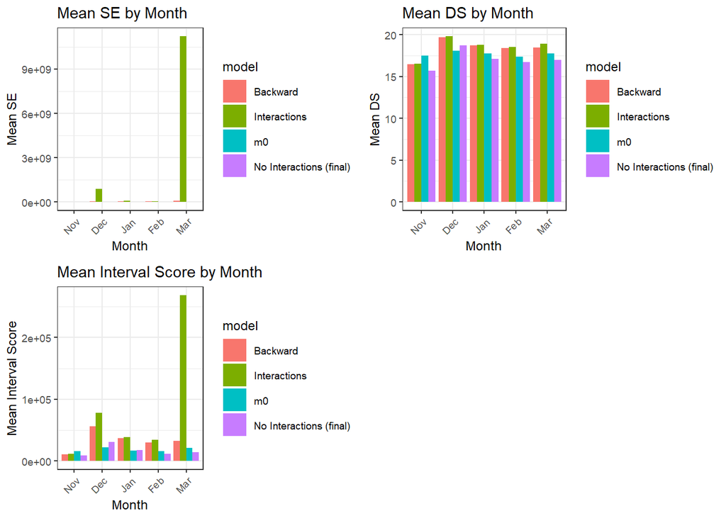

These graphs show that the interaction models are significantly worse for predicting particularly, the model with all interactions is much worse in March. Therefore, we will focus on “m0”, and “Final” for subsequent analysis.

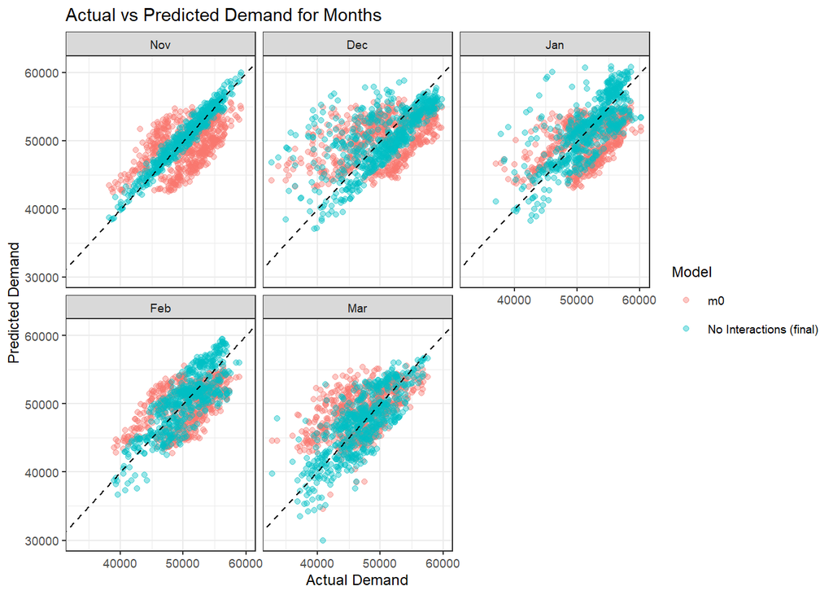

This regression plot compares Actual vs Predicted Demand for our models after rolling-window cross-validation. Points along the black dashed $y=x$ line indicate accurate predictions. The plots reveal that our final model performs far better than $m0$ and better in November and February, with tighter point clusters, while it struggles more in December, January, and March.

We can also assess performance across weekend and weekday.

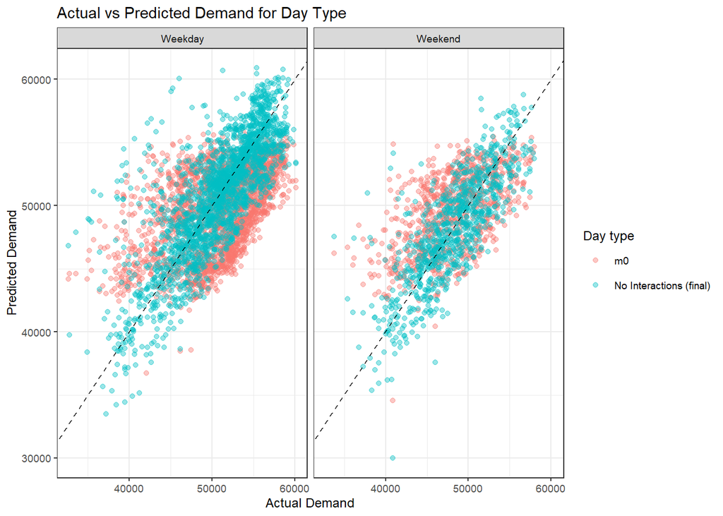

These plots show that our final model outperforms $m0$ for predicting weekdays, though the difference is less pronounced for weekends, possibly due to limited weekend data. To investigate further, we will analyze the scores in more detail.

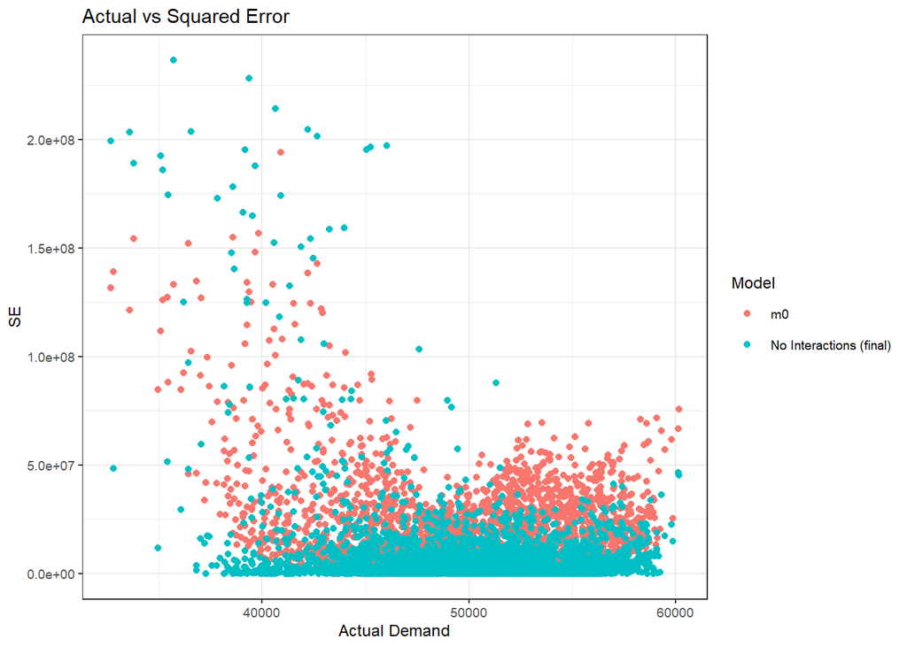

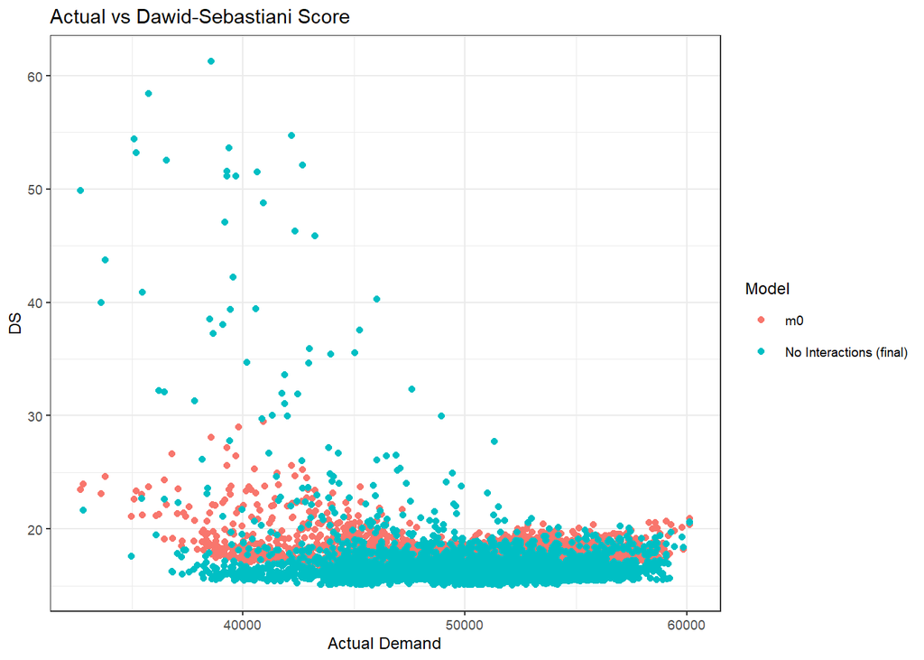

These plots show that the majority of scores for each value of $demand\_gross$ are better using our model than those for $m0$. Additionally, lower scores for higher gross demand indicate that our model is better at predicting extreme values.

## Exchangeability Test

To test if our final model is better at predicting than $m0$, we compare their prediction scores (SE and DS) by randomly swapping them within each cross-validation pair $(S_i^A, S_i^B)$. We use the test statistic $\frac{1}{N} \sum_{i=1}^n(S_i^A - S_i^B)$, and use a Monte Carlo approach to estimate the p-value for a test of exchangeability of predictions, with the alternative hypothesis that our model is superior to $m0$.

```r
kable(head(scores_diff))
```

| se_diff | ds_diff |
| --- | --- |
| 11150578 | 1.759473 |
| 11276030 | 1.790800 |
| 11269234 | 1.781415 |
| 11092881 | 1.751016 |
| 10883139 | 1.717616 |
| 11256390 | 1.779681 |

|  | se | ds |
| --- | --- | --- |
| p-values | 0 | 0 |

We can see that our models are so different that they are not exchangeable. Therefore there is evidence to reject the null hypothesis.

## Maximum Annual Demand Variation

We test how the maximum annual demand for the 2013-2014 winter season changes based on weather conditions from previous winters. Using data from each previous winter season, we simulate the 2013 maximum annual demand for 2013 by predicting values with our model.

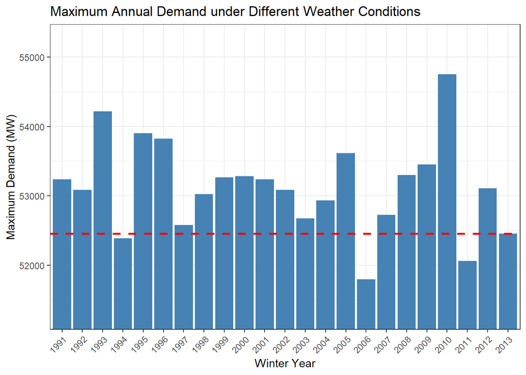

The plot shows that the maximum demand varies across weather years, ranging from around 51,800 MW (2006) to 54,750 MW (2010). Most years (except 1994, 2006, and 2011) predict higher demand than the actual 2013 value, possibly due to decreasing annual demand in recent years.

One possible explanation is that older weather years reflect colder and harsher winters, which would lead to increased heating demand. In contrast, the 2013/2014 winter may have been milder, potentially due to climate change, resulting in a lower actual peak demand. The overestimation of demand could also reflect shifts towards more energy-conscious behaviour and improved efficiency. Additionally, the decline in electricity demand in later years, driven by technological advancements, may explain why older weather conditions overpredict demand for the 2013/2014 season. Finally particularly high predictions for certain years (such as 2010) likely reflect extreme weather events, highlighting how sensitive peak demand is to severe conditions.

## Alternative temperature variable

Temperature is a key driver of electricity demand, especially during winter, when colder conditions increase heating usage. NESO currently use TEa rolling average of the previous day’s TO (3pm-6pm temperature), to account for temperature in demand forecasting. To assess whether TE is optimal, we first compared it to using TO directly in the model.

Using TO as the temperature variable resulted in a lower adjusted $R^2$ suggesting that daily temperature alone does not fully explain demand variation, whereas TE had an adjusted $R^2$ of 77.24%. This suggests that energy use responds to patterns of cold weather over several days, not just one day’s temperature.

We also experimented calculating TO over both a larger and shorter time frame (1pm-6pm and 5pm-6pm) for the TE variable, which resulted in lower $R^2$ values compared to using our current TE variable. Additionally, we explored rolling averages over 2, 3, and 5 days to investigate how incorporating more historical temperature data into the TE variable affects the model. As the window size increased, the adjusted $R^2$ decreased suggesting that adding too much past data dilutes the immediate temperature effects on demand.

| Time Frame (Days) | Adjusted $R^2$ |
| --- | --- |
| 2 | 0.7705355 |
| 3 | 0.7660329 |
| 5 | 0.7577941 |

All models incorporating alternative TE variables exhibited lower adjusted $R^2$ than the original that explained 77.24% of the data. This indicates that our current TE calculation provides the most explanatory power, as it better captures the variance in demand relative to the other variations considered.

## Model limitations

Our model relies on a linear regression framework, which carries several assumptions. We have assumed that the response variable, `demand_gross` is normally distributed, and that errors, $\varepsilon_i \sim \mathcal{N}(0, \sigma^2)$, are independent and identically distributed with constant variance (homoscedasticity). However, these assumptions can be problematic in a time-series context, where both the mean and variance of the data may change over time. Our explanatory variables may also not be independent, and by ignoring interactions between them, we could be underfitting our data. Nonetheless, residual plots indicate that the linear model performs reasonably well for the data at hand, with no major violations of assumptions.

Additionally, our model is constrained by the quality of the data itself. As we are only using one dataset, there could be missing explanatory variables that haven’t been taken into account. For example, our model aims to predict energy demand across the whole of the UK, but usage will vary from region-to-region, and be especially different in larger cities compared to remote areas. Our model could also consider bottlenecks such as Christmas, may experience unusual spikes in demand that the model does not account for explicitly. With our current dataset, we only consider winter months, which means the model is much less accurate for predicting energy demand year-round.

Environmental and societal changes also present challenges. Variables like $solar_S$ and $temp$ are influenced by ongoing climate change, and shifts in consumer behaviour, energy efficiency, and policy may mean that historical demand data, especially from earlier years, are less representative of current or future patterns. Incorporating more recent data could help address these issues and improve model relevance.

Lastly, while linear regression is computationally efficient and interpretable, it may not scale well to larger or more complex datasets. While it is performing well with prediction here, it could be unsuited to larger datasets as the electricity system evolves. NESO may benefit from exploring more flexible modelling techniques such as random forests or other machine learning techniques, which can better handle non-linear relationships and interactions without overfitting.

# Conclusion

Our analysis finds that a simpler model is preferred for prediction, as including interactions results in over-fitting. This is shown by comparing our final model with both a full interaction model and a backward stepwise regression model. While interaction terms can capture complex relationships between variables, they also substantially increase the number of parameters, making the model more sensitive to noise in the training data. This likely explains why the interaction model, despite fitting the historical data closely, performed worse in external prediction.

Though the model excludes interaction terms, it still achieves a relatively high adjusted $R^2$ indicating a good fit to historical data. While excluding interactions may underfit subtle relationships, it is computationally less intensive for NESO to run, while maintaining high prediction accuracy. However, the assumption of independence among predictors may limit the model’s scalability as more complex or higher-resolution data become available in future. Exploring selective interactions or nonlinear effects could be a worthwhile following investigation.

By performing rolling-window cross-validation, we have considered the time-series nature of the data, making sure not to train on future data to test on past data. As our model has the lowest mean DS score of 17.03901, it has high prediction accuracy. This supports NESO’s long-term planning goals. By focusing only on winter months, the period of greatest risk for electricity shortfalls, we ensure the model is most effective where it matters most. This will mitigate the possibility that daily peak demand will exceed maximum supply capacity. By analysing our prediction by month, our final model will enable NESO to anticipate shifts in electricity demand, supporting informed decision-making.

# Code Appendix

```r
# Group 50
# Place the code needed in the Report_project02.Rmd, including documentation.
#

#' Model Comparison
#'
#' Compare R^2 and other metrics of different linear models for our data
#'
#' @param lms vector of different linear models to compare, all of the form m0 <- lm(formula, data)
#' @param names names of the linear models we are comparing
#' @param datalist a list of the data that we are using for each model in lms

comparison <- function(formulas, names, data){

  # Initialise a dataframe for the results
  results <- data.frame(
    Model = character(),
    R_squared = numeric(),
    Adjusted_R_squared = numeric(),
    RMSE = numeric(),
    stringsAsFactors = FALSE
  )

  # Loop over the models
  for (i in 1:length(formulas)) {

    # Extract models and names from the inputted dataframe
    model <- lm(formulas[[i]], data)
    model_name <- names[i]

    # Calculate R-squared and Adjusted R-squared
    model_summary <- summary(model)
    r_squared <- model_summary$r.squared
    adj_r_squared <- model_summary$adj.r.squared

    # Calculate RMSE (Root Mean Squared Error)
    predictions <- predict(model, newdata = data)
    mse <- mean((data[["demand_gross"]] - predictions)^2)
    rmse <- sqrt(mse)

    # Append the results to the data frame
    results <- rbind(results, data.frame(
      Model = model_name,
      R_squared = r_squared,
      Adjusted_R_squared = adj_r_squared,
      RMSE = rmse
    ))
  }
  # Return the comparison data frame
  return(results)
}

#' Historical Modelling
#'
#' Testing our models on historical data, finding confidence
#' and prediction intervals
#'
#' @param lm the linear model we are testing
#' @param data the dataset that we are modelling on

lm_predicting <- function(formula, data){

  # predict using the linear model
  confidence <- predict.lm(object = lm(formula, data), interval = "confidence", level = 0.95)
  prediction <- predict.lm(object = lm(formula, data), newdata = data,
                           se.fit = TRUE, interval = "prediction", level = 0.95)

  # create dataframe with predicted data
  results <- as.data.frame(data)

  # find mean, standard deviation and lower & upper bounds for the predicted data
  results$mean_pred <- prediction$fit[, "fit"]
  results$sd <- sqrt(prediction$se.fit^2 + prediction$residual.scale^2)
  results$lwr_pi <- prediction$fit[, "lwr"] - 1.96 * results$sd
  results$upr_pi <- prediction$fit[, "upr"] + 1.96 * results$sd
  results$mean_ci <- confidence[, "fit"]
  results$lwr_ci <- confidence[, "lwr"]
  results$upr_ci <- confidence[, "upr"]

  # create a dataframe with the analysed prediction data
  p <- data.frame(mean_pred = results$mean_pred, sd = results$sd, lwr_pi = results$lwr_pi, upr_pi = results$upr_pi, mean_conf = results$mean_ci, lwr_ci = results$lwr_ci, upr_ci = results$upr_ci)

  return(p)
}


#' Rolling Cross-Validation
#'
#' Using a 3-1 year split, based on start_year, the year that each winter in the
#' dataset starts. Predicting the demand for the next year based on the previous
#' 3 years
#'
#' @param data the dataframe we are modelling over
#' @param formula the formula of the chosen linear model

monthly_rolling_model <- function(data, formula) {

  # initialise a dataframe for storing everything
  scores <- data.frame()

  # put all the winters in order, removing the first 3 in order to train
  test_years <- sort(unique(data$start_year))[-(1:3)]

  # window sizes
  training_window <- 3
  testing_window <- 1

  # We want to split data by year
  for (test_year in test_years) {

    # split data for training and testing
    train_data <- data %>% filter(start_year >= (test_year - training_window) & start_year < test_year)
    test_data <- data %>% filter(start_year == test_year)

    # fit the model on train data, predict on test data
    fit <- lm(formula, data = train_data)
    pred <- predict(fit, newdata = test_data, se.fit = TRUE, interval = "prediction", level = 0.95)

    # observed values of gross demand
    actual <- test_data$demand_gross

    # prediction metrics
    mean_pi <- pred$fit[, "fit"]
    sd_pi <- sqrt(pred$se.fit^2 + summary(fit)$sigma^2)
    lwr_pi <- pred$fit[, "lwr"]
    upr_pi <- pred$fit[, "upr"]

    # scores
    se_pi <- (actual - mean_pi)^2
    ds_pi <- (actual - mean_pi)^2 / sd_pi^2 + 2 * log(sd_pi)
    int_pi <- upr_pi - lwr_pi + (2 / 0.05) * ((lwr_pi - actual) * as.integer(actual < lwr_pi) + (actual - upr_pi) * as.integer(actual > upr_pi))

    # add everything to our dataframe in each iteration of this loop
    new_row <- data.frame(
      year = test_year,
      month = test_data$month,
      actual = actual,
      mean = mean_pi,
      se = se_pi,
      ds = ds_pi,
      int = int_pi,
      sd = sd_pi,
      lwr = lwr_pi,
      upr = upr_pi,
      daytype = test_data$daytype
    )

    scores <- rbind(scores, new_row)
  }

  return(scores)

}

#' Simulating Maximum Demand
#'
#' Simulating the maximum annual demand for 2013 by using the data from a previous
#' winter season.
#'
#' @param weather_year the year of the winter season

simulate_max_demand <- function(weather_year) {

   # Get weather data for the specific year
  yearly_weather <- demand %>%
    filter(start_year == weather_year) %>%
    dplyr::select(day_month, wind, solar_S, TE)

  # Combine with 2013-14 structure
  combined_data <- demand_2013_structure %>%
    left_join(yearly_weather, by = "day_month")

  # Predict demand
  combined_data$predicted_demand <- predict(demand_model, newdata = combined_data)

  # Return the maximum predicted demand
  combined_data %>%
    summarise(
      simulated_year = 2013,
      weather_year = weather_year,
      max_demand = max(predicted_demand, na.rm = TRUE))
}

#' Simulating different TE
#'
#' This function calculates the adjusted \( R^2 \) for different window sizes and compares the performance of models with rolling TE.
#'
#' @param data the given dataframe
#' @param window_sizes A numeric vector of different window sizes (in days) to be used for calculating the rolling average of the TE variable
calculate_rolling_r2 <- function(data, window_sizes) {# Ensure the Date is in POSIXct format
  data <- data %>%
    mutate(Date = dmy_hm(Date))

  # Store results
  results <- data.frame(window = numeric(), adj_r_squared = numeric())

  # Loop through the window sizes
  for (window_size in window_sizes) {

    # Create the rolling average column for the given window size
    data <- data %>%
      arrange(Date) %>%
      mutate(rolling_TE = rollapply(TE, width = window_size, FUN = mean, align = "right", fill = NA))

    # Fit the linear model using the rolling TE
    model <- lm(demand_gross ~ wind + solar_S + rolling_TE + day + month + poly(year, 3), data = data)

    # Extract the adjusted R-squared value
    adj_r_squared <- summary(model)$adj.r.squared

    # Store the result
    results <- rbind(results, data.frame(window = window_size, adj_r_squared = adj_r_squared))
  }

  return(results)
}
```